# Part 1 — Annotation descriptives

## Gender

Author gender, examined two ways: first-author gender and all-author gender by year, and gender composition across the full author list per paper.

### By year

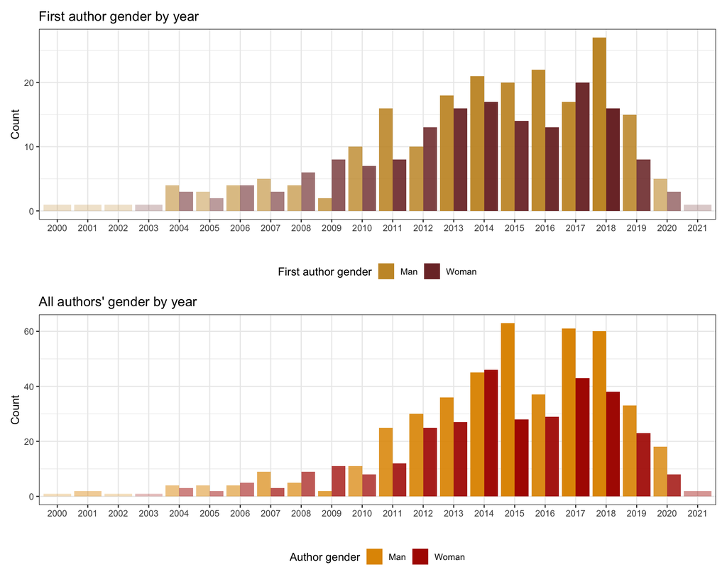

Top: first author only, one bar per gender per year — faint bars mean few papers published that year. Bottom: every author position pooled (order not preserved), so a multi-author paper contributes more than one tally — faint bars there mean few author-slots that year, not few papers. Same Wilson-interval fade used throughout this document, computed against the relevant denominator for each panel.

### Composition across the full author list

First-author gender and the order-blind pool above don’t capture gender **composition per paper** (all-male vs. all-female vs. mixed) or **order** within a paper.

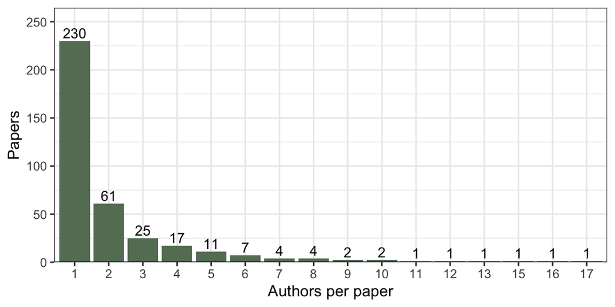

Several ways of collapsing a per-paper gender sequence into a single cross-tabbable category are compared below — a strict all-same-vs-mixed split, a majority-based split, and a version that separates solo authorship out from multi-author teams (since “all-male” means something different for n=1 than for a genuinely uniform team).

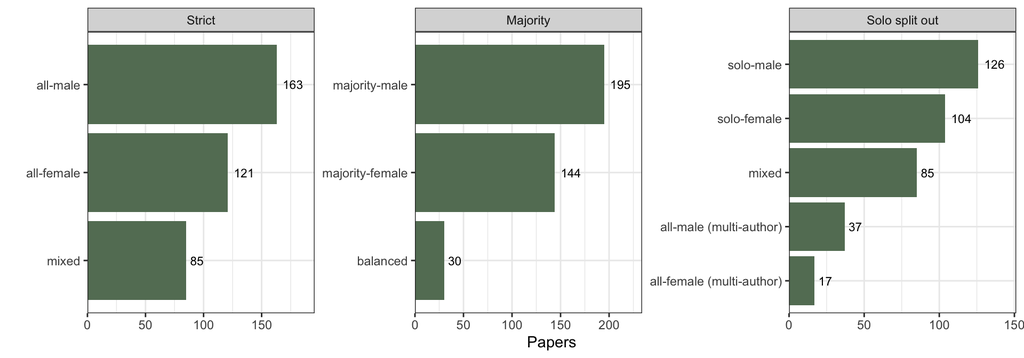

## Topic

A paper can carry a Primary-coded topic (the coder’s judgment of its main focus) and any number of Secondary-coded topics (also present, but not the main focus) — see the codebook for the exact scope of each topic category. Charts below count a paper toward a topic if it carries either value, so a paper coded with one Primary and two Secondary topics contributes to three bars — counts and proportions are not mutually exclusive across topics and will not sum to the corpus total. This applies throughout this document, not just to Topic.

### Totals

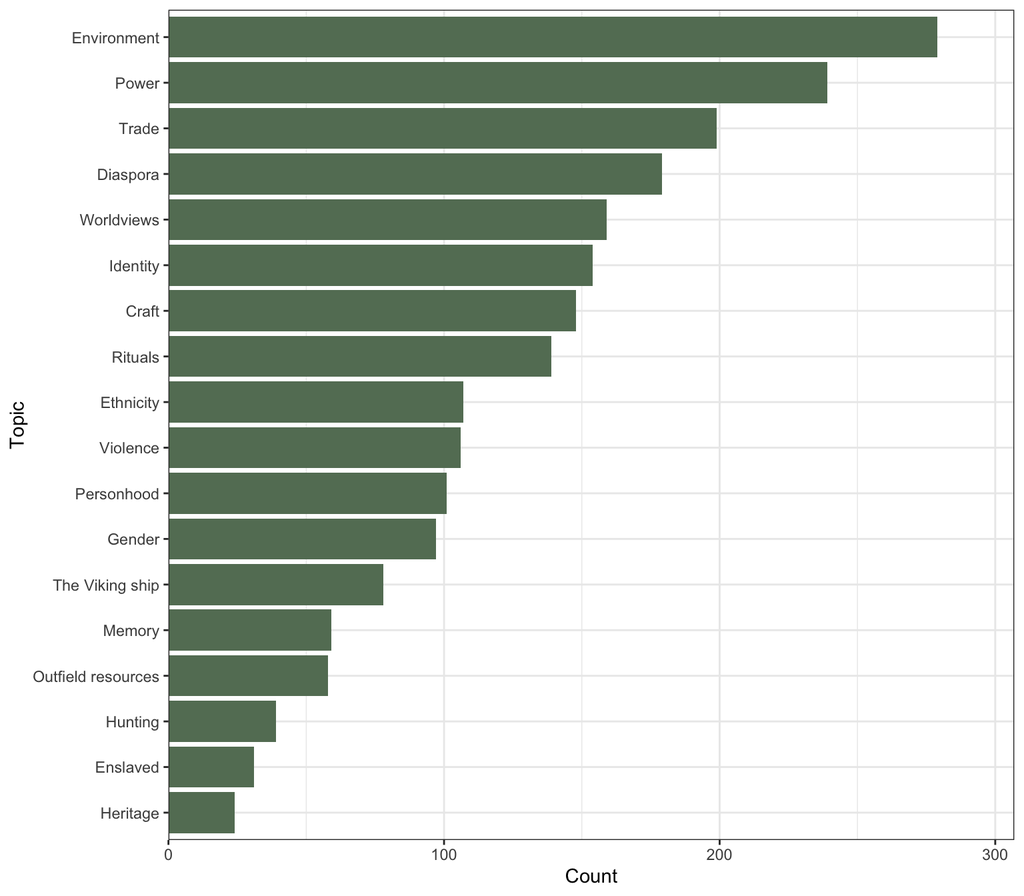

A paper counts toward a topic once, regardless of how many values it carries (Primary or Secondary — see above).

### Over time

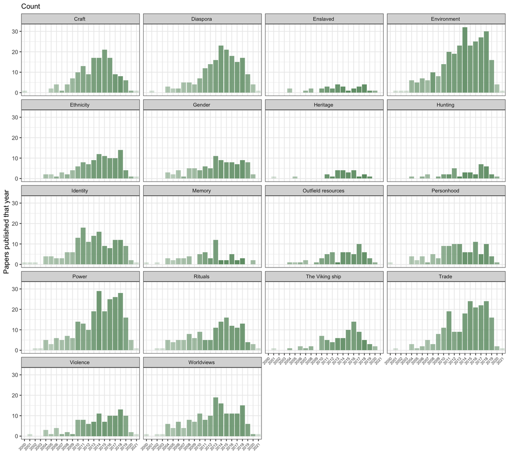

Papers per year, per topic. Faint bars: few papers that year.

**By year**

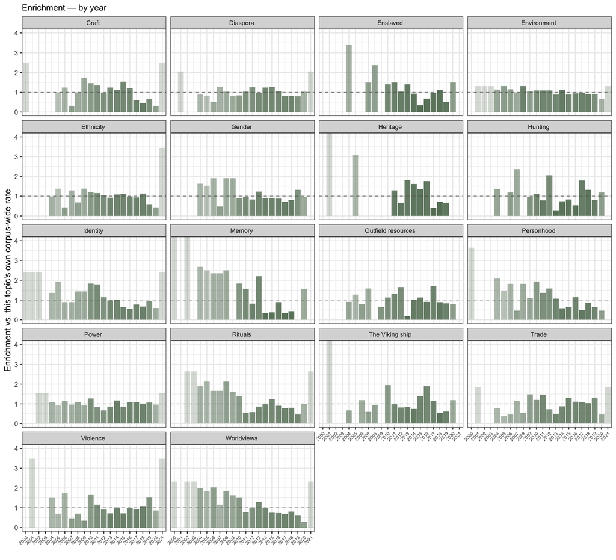

Enrichment per year, per topic. Faint bars: few papers that year.

**Smoothed trend**

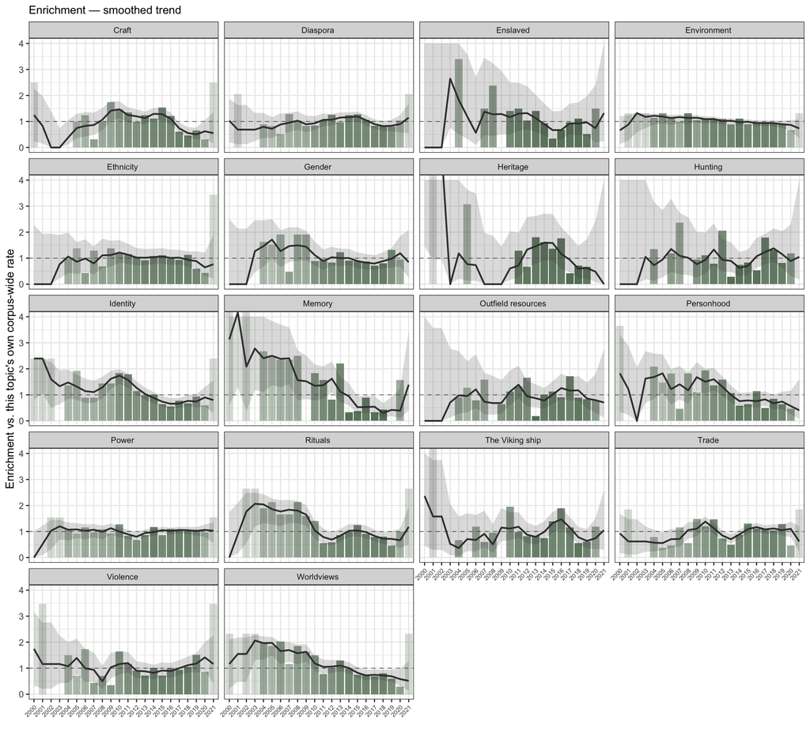

Same enrichment bars, with a 3-year rolling average and its own confidence band.

### Co-occurrence

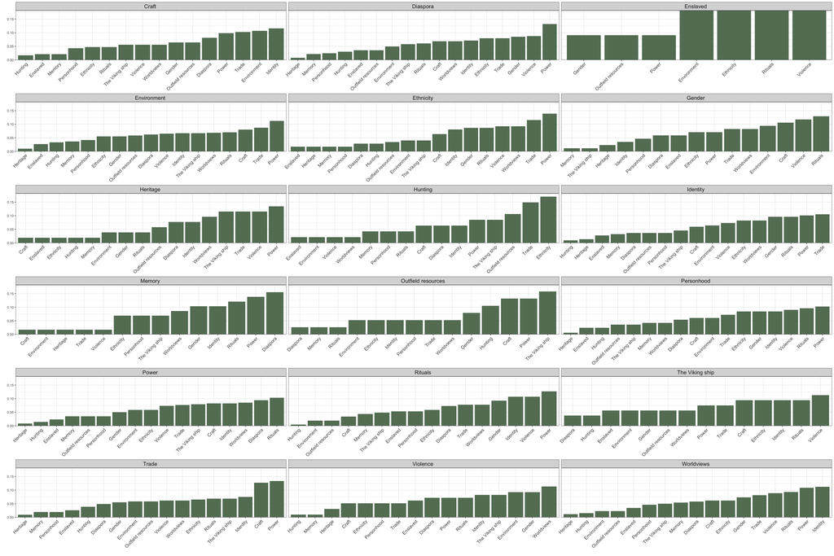

Directional: given a paper’s Primary-coded topic (the facet), how often is each other topic marked Secondary on the same paper.

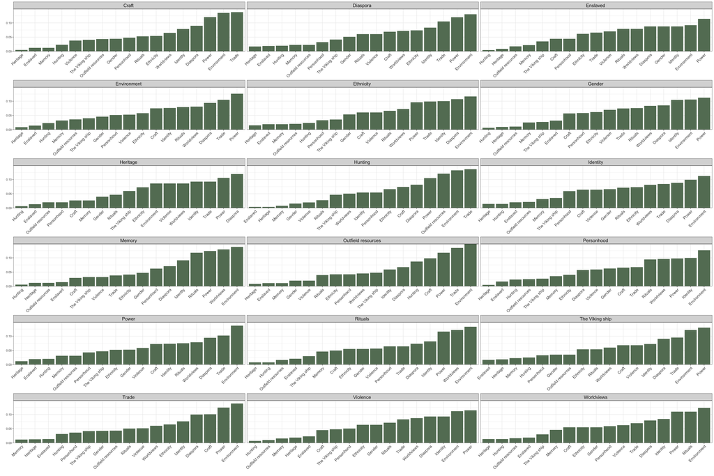

Undirected: which topics appear together at all, regardless of rank — present if either value is carried, pairing symmetric.

### By first-author gender

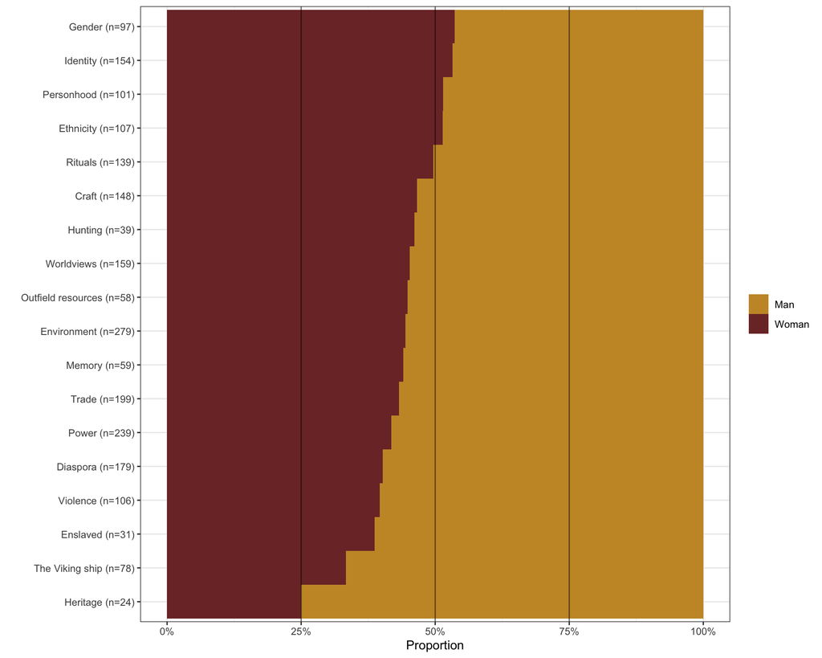

Proportion of papers by first-author gender, within each topic. Topics are labelled with their n; horizontal lines mark 25/50/75% for reference. Raw proportions, not corrected for the corpus-wide gender split.

### By full-author-list gender composition

Every paper’s authors, sorted into one of five groups: solo female author, solo male author, an all-female team, an all-male team, or a mixed-gender team. Solo authorship is kept separate from team composition — a single female author isn’t the same thing as a team that happens to be all women, and lumping them together would hide that difference.

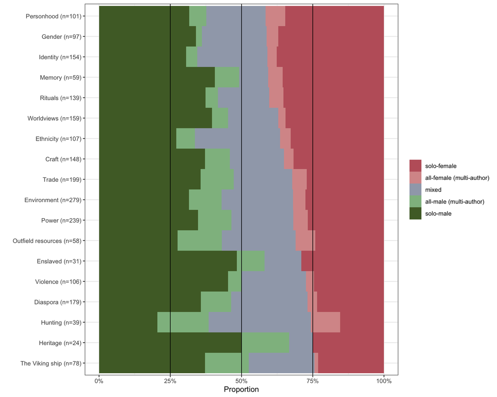

Proportion of papers by author-list gender composition (solo female/male, all-female/all-male team, mixed team), within each topic. Horizontal lines mark 25/50/75% for reference.

### Mixed-gender authorship only

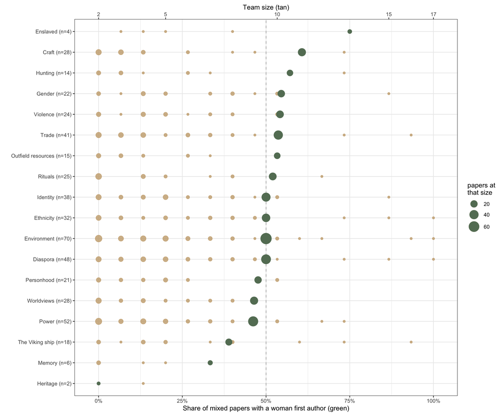

Each topic has two overlaid series on the same row, using different x-axes. Green dots (bottom axis): share of that topic’s mixed-gender papers with a woman first author, dot size is the number of mixed papers behind that topic. Tan dots (top axis): every distinct author-team size found among that topic’s mixed papers, dot size is how many papers have that size. Dashed vertical line marks 50% on the green (bottom) axis only.

## Method

### Totals

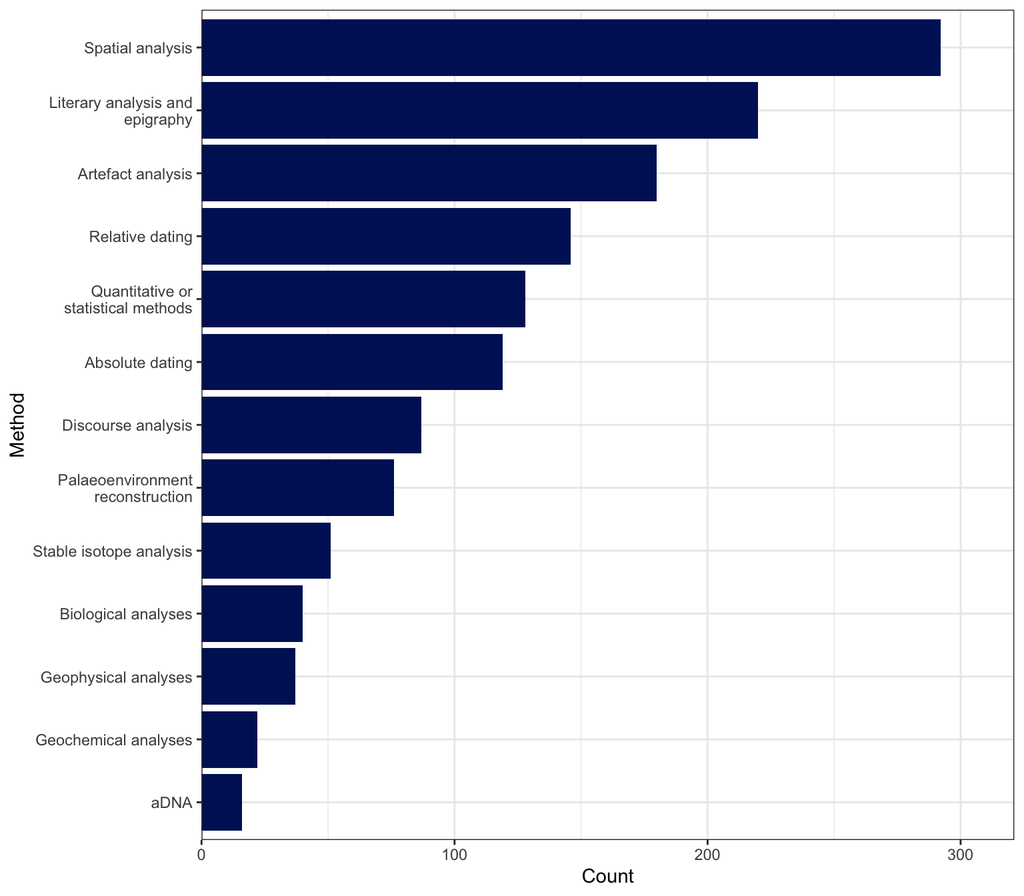

A paper counts toward a method once, regardless of Primary/Secondary status.

### Over time

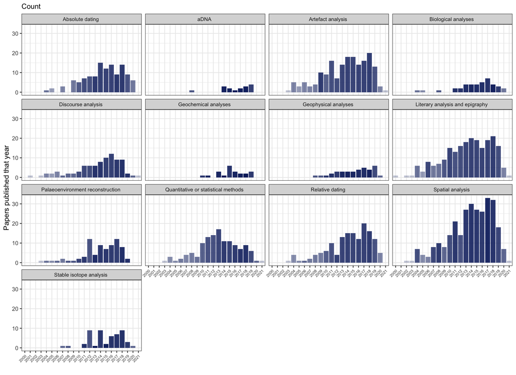

Papers per year, per method. Faint bars: few papers that year.

**By year**

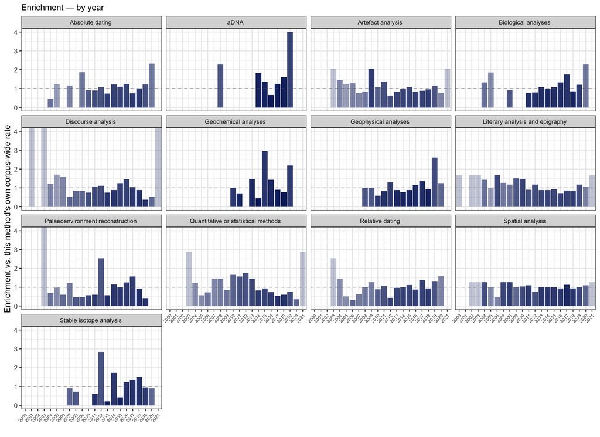

Enrichment per year, per method. Faint bars: few papers that year.

**Smoothed trend**

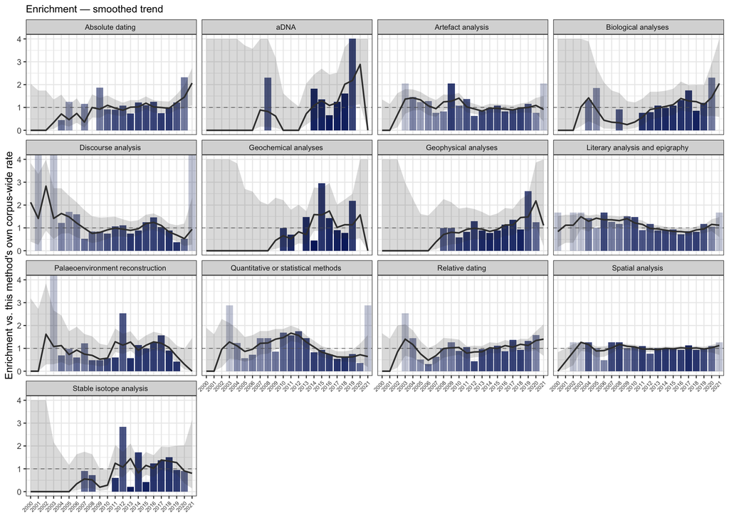

Same enrichment bars, with a 3-year rolling average and its own confidence band.

### Co-occurrence

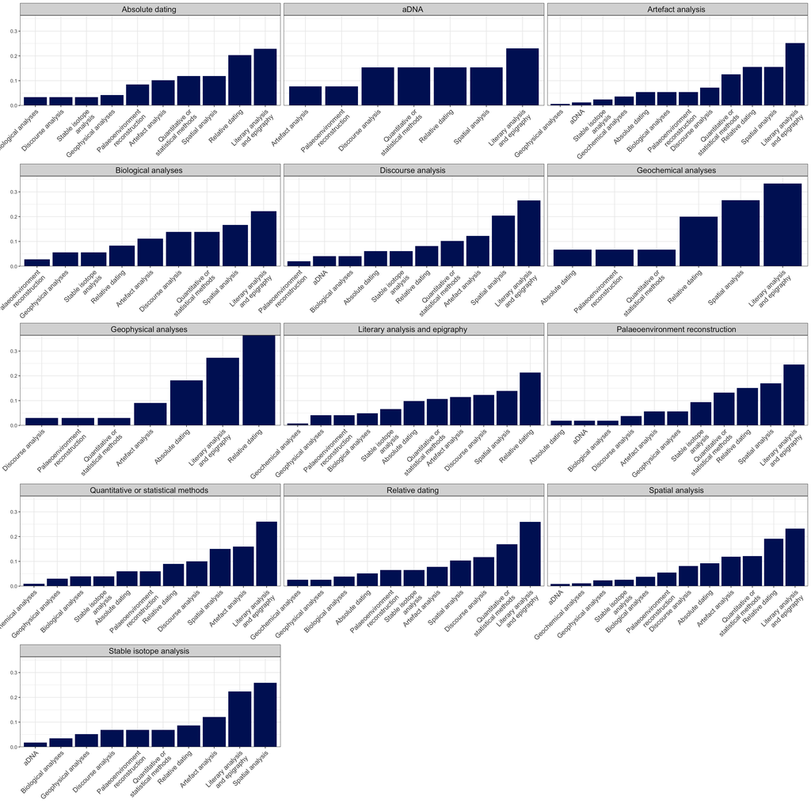

Directional: given a paper’s Primary-coded method (the facet), how often is each other method marked Secondary on the same paper.

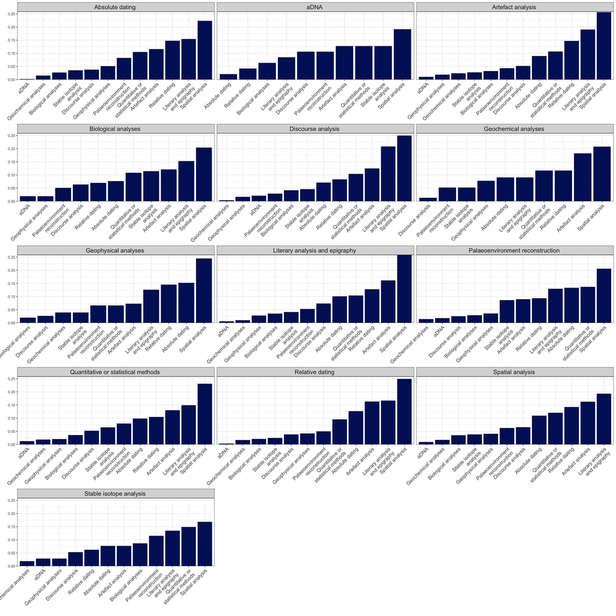

Undirected: which methods appear together at all, regardless of rank — present if either value is carried, pairing symmetric.

### By first-author gender

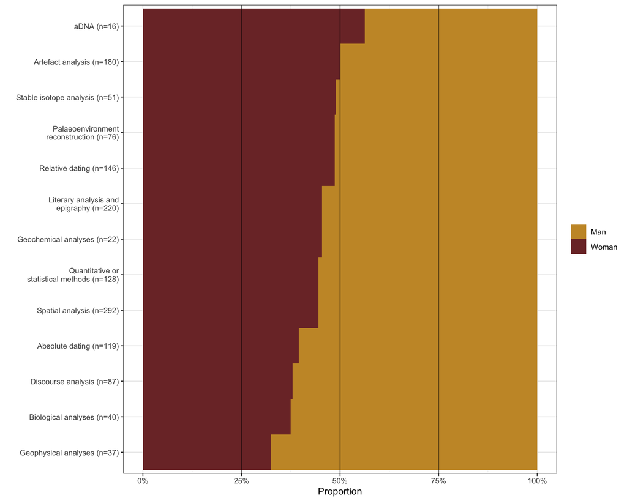

Proportion of papers by first-author gender, within each method. Methods are labelled with their n; horizontal lines mark 25/50/75% for reference. Raw proportions, not corrected for the corpus-wide gender split.

### By full-author-list gender composition

Every paper’s authors, sorted into one of five groups: solo female author, solo male author, an all-female team, an all-male team, or a mixed-gender team. Solo authorship is kept separate from team composition, so a single author’s gender isn’t treated as if it were a team’s composition.

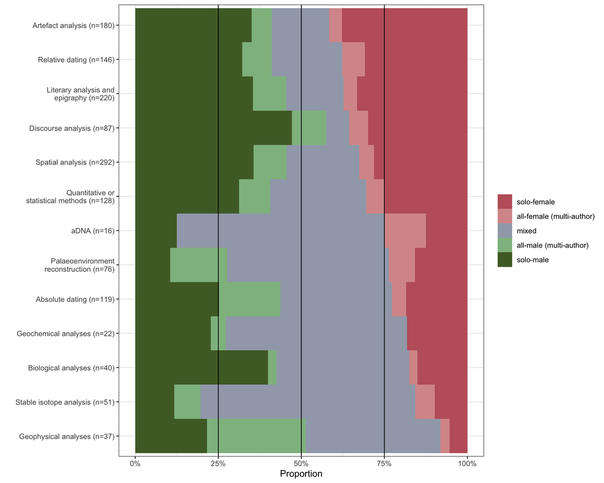

Proportion of papers by author-list gender composition (solo female/male, all-female/all-male team, mixed team), within each method. Horizontal lines mark 25/50/75% for reference.

### Mixed-gender authorship only

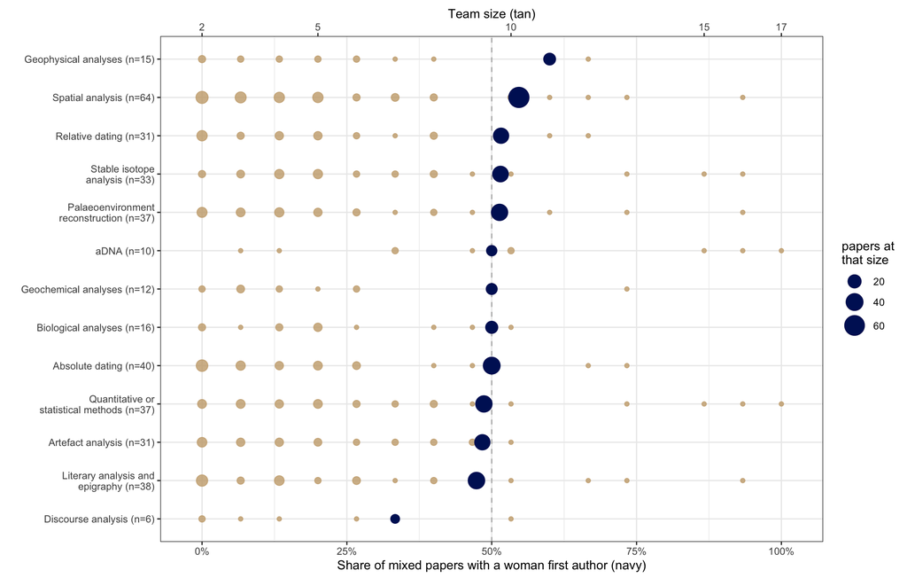

Each method has two overlaid series on the same row, using different x-axes. Navy dots (bottom axis): share of that method’s mixed-gender papers with a woman first author, dot size is the number of mixed papers behind that method. Tan dots (top axis): every distinct author-team size found among that method’s mixed papers, dot size is how many papers have that size. Dashed vertical line marks 50% on the navy (bottom) axis only.

## Source of evidence

### Totals

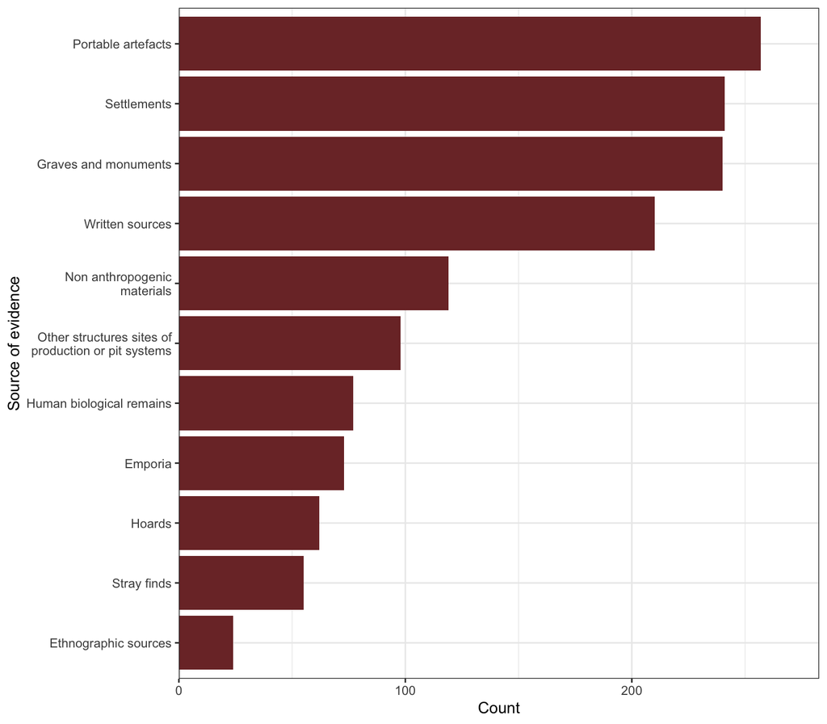

A paper counts toward a source once, regardless of Primary/Secondary status.

### Over time

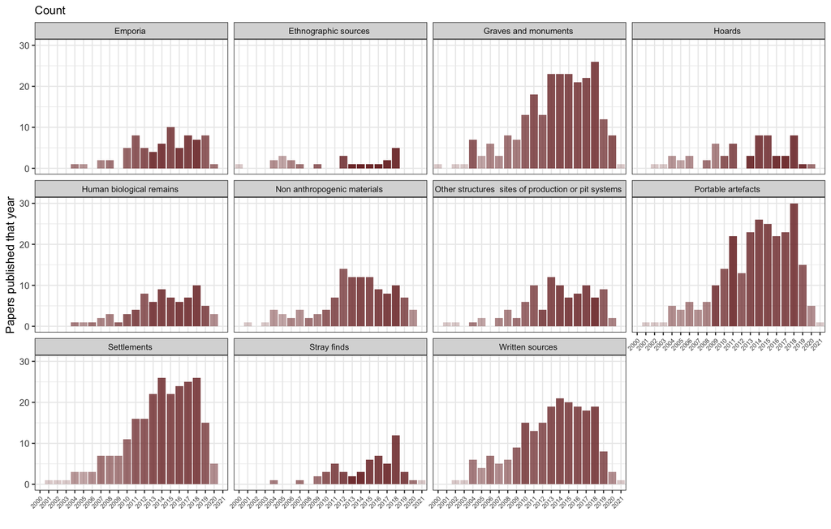

Papers per year, per source. Faint bars: few papers that year.

**By year**

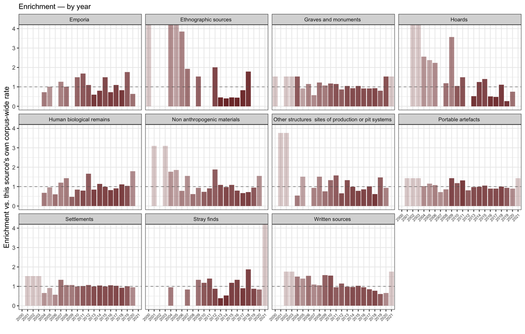

Enrichment per year, per source. Faint bars: few papers that year.

**Smoothed trend**

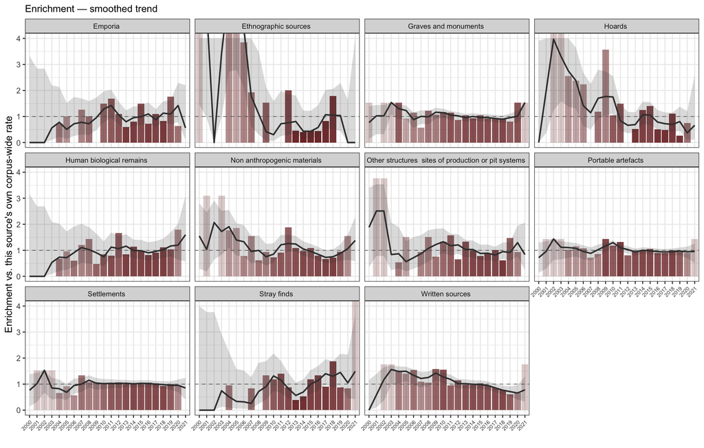

Same enrichment bars, with a 3-year rolling average and its own confidence band.

### Co-occurrence

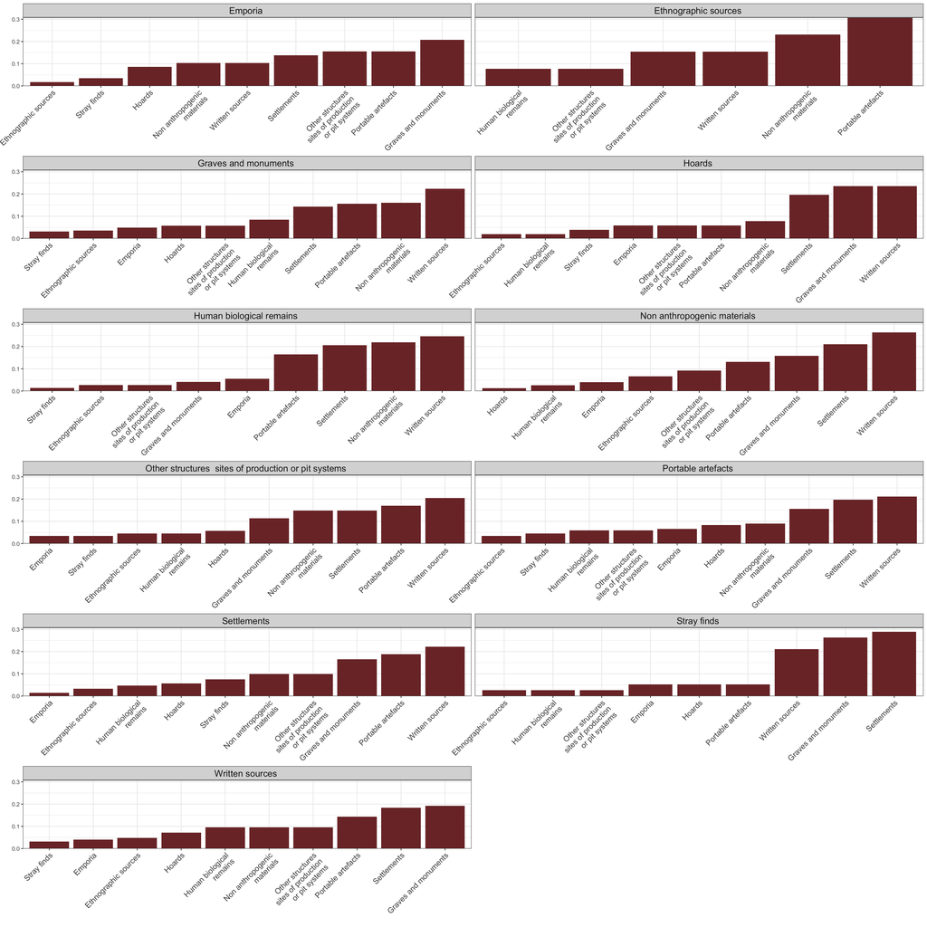

Directional: given a paper’s Primary-coded source (the facet), how often is each other source marked Secondary on the same paper.

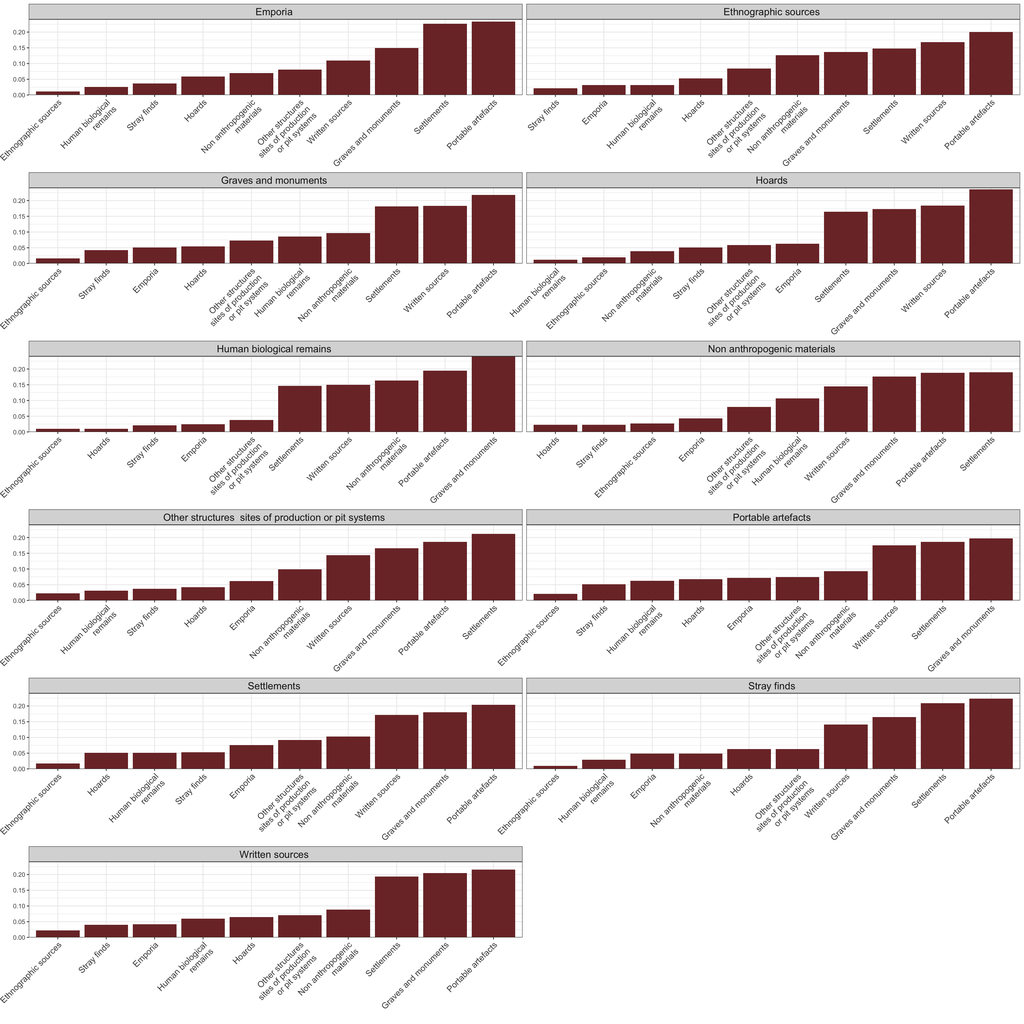

Undirected: which sources appear together at all, regardless of rank — present if either value is carried, pairing symmetric.

### By first-author gender

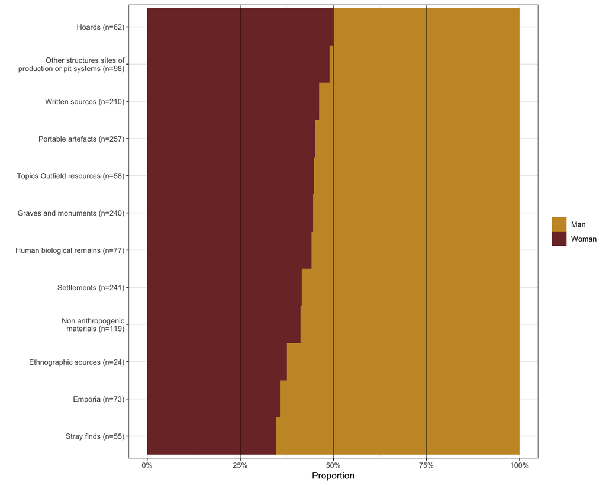

Proportion of papers by first-author gender, within each source. Sources are labelled with their n; horizontal lines mark 25/50/75% for reference. Raw proportions, not corrected for the corpus-wide gender split.

### By full-author-list gender composition

Every paper’s authors, sorted into one of five groups: solo female author, solo male author, an all-female team, an all-male team, or a mixed-gender team. Solo authorship is kept separate from team composition, so a single author’s gender isn’t treated as if it were a team’s composition.

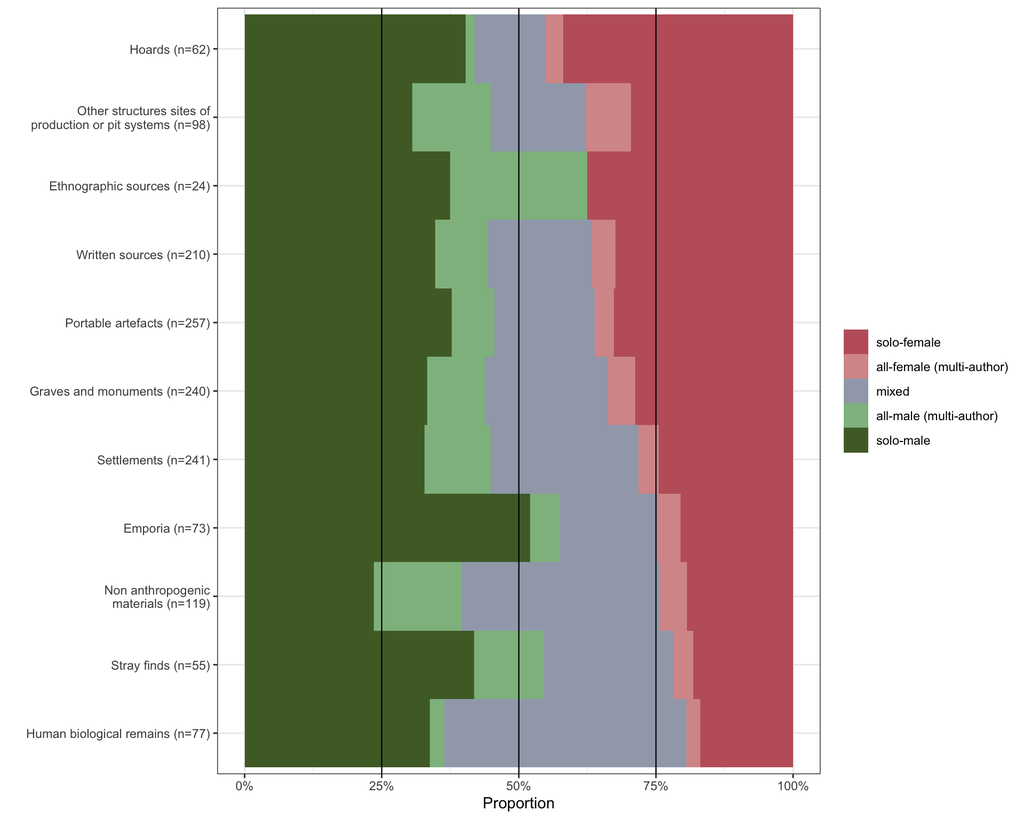

Proportion of papers by author-list gender composition (solo female/male, all-female/all-male team, mixed team), within each source of evidence. Horizontal lines mark 25/50/75% for reference.

### Mixed-gender authorship only

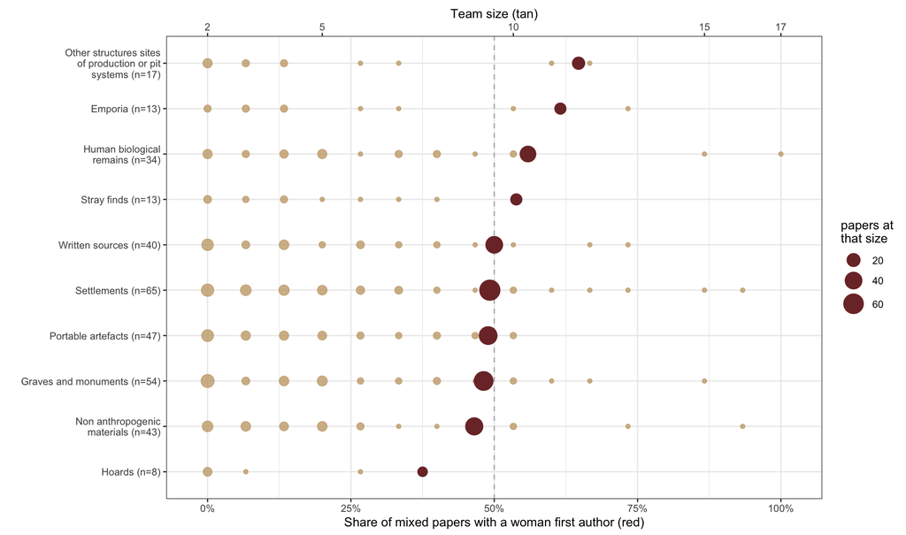

Each source of evidence has two overlaid series on the same row, using different x-axes. Red dots (bottom axis): share of that source’s mixed-gender papers with a woman first author, dot size is the number of mixed papers behind that source. Tan dots (top axis): every distinct author-team size found among that source’s mixed papers, dot size is how many papers have that size. Dashed vertical line marks 50% on the red (bottom) axis only.

## Region

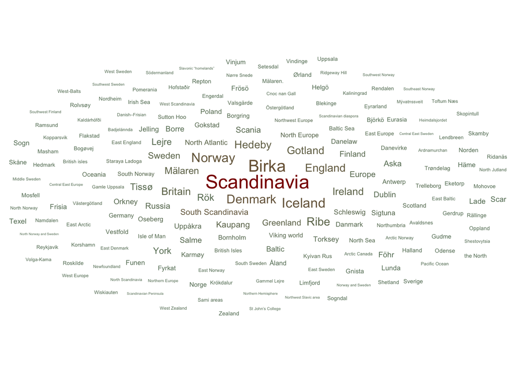

### Matching to Wikidata

Region is free text drawn directly from each paper, not a controlled vocabulary: spelling variants and mixed specificity (continent, country, named site) count as distinct terms in the word cloud above. Wikidata is used to consolidate these to real places with coordinates. Pleiades, Pelagios/Peripleo, and iDAI.gazetteer were considered and set aside: all three are institutionally anchored in Mediterranean/classical-world antiquity, with no confirmed non-trivial coverage of Viking-Age Scandinavia. Wikidata was used instead for its dense, well-curated coverage of Scandinavian archaeological sites and structured multilingual labels/aliases, which handle spelling variants (Danmark/Denmark) close to for free.

The chunks below call Wikidata’s SPARQL endpoint and so require outbound network access; they default to `eval: false` and do not run on a normal render of this document. Run them explicitly (flip `eval: true`) when the lookup table needs building or refreshing, then leave them off again — the rest of this section reads the resulting static CSV, same as Topic, Method, and Source read their own derived data.

**Coverage probe.** Before matching all tokens, check hit rate on the most frequent ones — this is the actual empirical check for whether Wikidata is workable here, not an assumption.

**Check `probe_results` before continuing.** If the hit rate on real, frequent Viking-Age placenames (Birka, Hedeby, Kaupang, Ribe, Uppåkra, Tissø, etc.) is low, the class filter above may be too narrow — Wikidata items for archaeological sites are not always tagged with exactly these `instance of` values — and the SPARQL query needs revising before running the full match. A high count under `contains fallback` is expected and fine — it means the class filter is right but the corpus token is a shortened form of the item’s real label (e.g. “Gokstad” for “Gokstad Mound”), not a coverage problem.

**Full match**, once the probe above confirms acceptable coverage. This single chunk matches every token, separates out macro-region terms that can’t resolve to a point, and writes the resulting lookup table plus a manual-review export, all together (previously three separate chunks; merged into one so a single `eval` flag controls the whole matching-to- saved-file pipeline, since matching without saving the result was wasted work run for nothing):

**Nesting (optional).** Every matched place is currently flat: “Birka,” “Vestfold,” “Sweden,” and “Scandinavia” are independent tokens with no recorded relationship between them, even though Birka is genuinely in Uppland, Sweden, Scandinavia. This chunk resolves three nesting levels for each matched place, each as its own column:

Like the matching chunks above, this calls Wikidata and needs network access; it stays off by default.

Country resolution here runs on the raw matched coordinates, before the `known_bad_matches` correction is applied (that correction lives in region-joined below, and only nulls the bad matches’ `lat`/`lon`/etc. there, not here). So resolving nesting right after this chunk can produce a real `country` value for a token later corrected to `no_match` — e.g. “Repton” resolving to “United States” here, even though `region-joined` clears it entirely downstream. That correction was extended to also null `admin_region`/`country`/`super_region` when present, so this is handled automatically as long as `region-joined` runs after nesting, which it always does on a normal render.

Once `region_lookup.csv` exists, the resulting `region_df` joins region to gender, topic, method, source, and year the same way those variables already join to each other elsewhere in this document — by `citekey`, using the same Wilson-interval and by-year machinery.

### Where the corpus is set

**What the map includes.** A region token appears as a point only if it has a real matched coordinate, is not a macro-region term (Scandinavia, Viking world, East Baltic, and the rest of that list — excluded even when Wikidata does return a coordinate for the concept, since a single point can’t honestly represent an area that broad), and falls within a fixed plotting bounding box (lat 25-80, lon -60 to 100) that excludes a couple of real but geographically irrelevant matches (Oceania, Pacific Ocean) which would otherwise force the whole map out to a global scale. Dot size is the number of papers carrying that exact region token — 20 papers all tagged “Birka” produce one dot sized 20, not 20 separate dots. The map’s crop is computed from the real spread of whatever points pass all three filters, with a fixed margin, so it always fits what’s actually shown rather than a hardcoded guess.

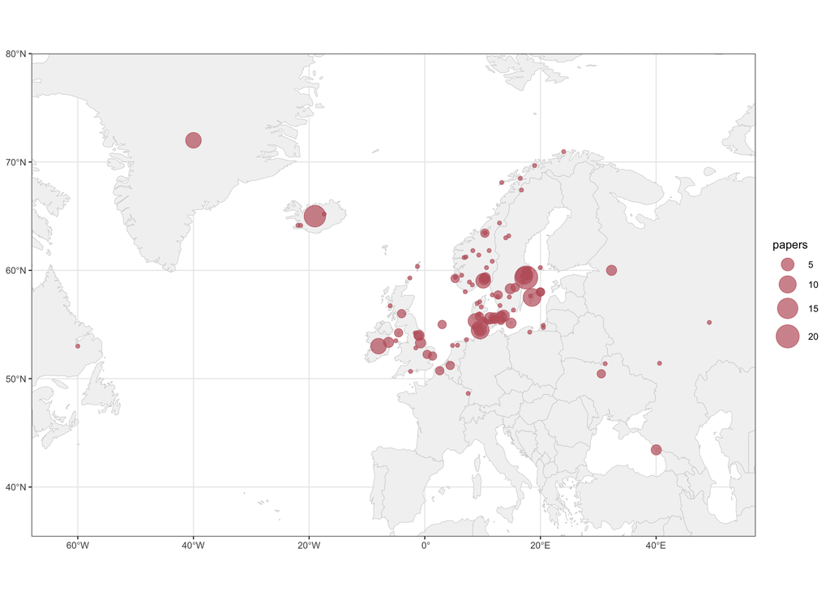

Named places mentioned in the corpus, sized by number of papers. Macro-region terms (Scandinavia, Viking world, and similar) are excluded even when Wikidata returns a coordinate for them, since a single point cannot honestly represent an area that broad — see the totals chart below for those. Cropped to the real spread of the remaining matched coordinates with a margin; a handful of correct but far-flung matches (e.g. Oceania, Pacific Ocean — real tokens in the corpus, real Wikidata matches) fall outside this crop and are not shown on the map.

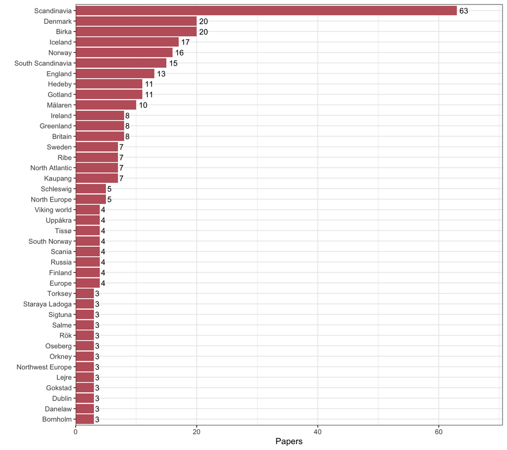

Every region token with at least 3 tagged papers, point-matched places and macro-region terms together, ranked by raw count.

**By country (optional, requires country nesting).** The chart above keeps every region token flat, “Birka” and “Sweden” and “Scandinavia” are three separate bars even though Birka is in Sweden — deliberately, since the paper’s own choice of a site-level or country-level term is itself part of what the data says, not noise to collapse away. This alternate view rolls site-level tags up to the country they’re actually in, using the `country` column added by the region-nesting chunk above (only present once that chunk has been run). A paper tagged “Birka” counts toward Sweden here even if it was never separately tagged “Sweden.” Macro-region terms (Scandinavia, Viking world) still have no single country and are excluded from this view.

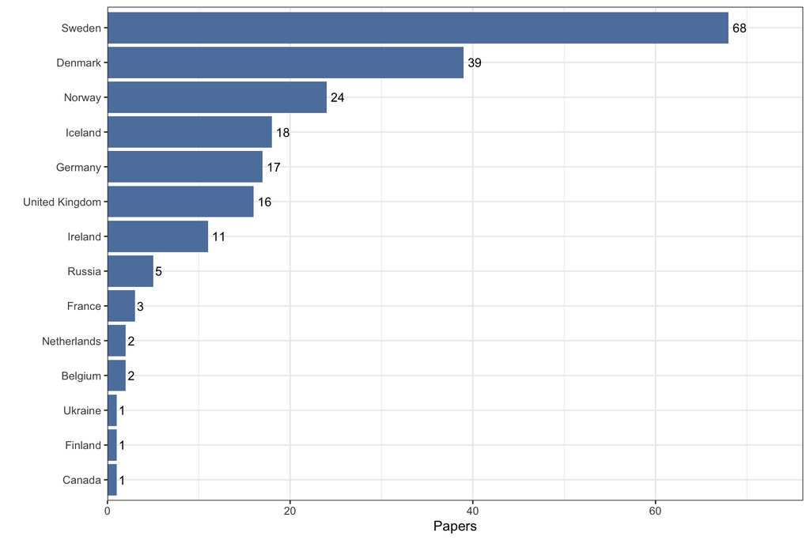

Papers per country, site-level tags rolled up to their containing country.

### Topic, method, and source by region

Same problem as gender composition above: most region tokens have too few papers to support a per-region proportion chart. Enrichment solves this differently — restricted to regions with at least 5 tagged papers, each cell shows that region’s coverage of a topic/method/source divided by that category’s own rate across the whole corpus (1.0x = corpus average), the same measure already used for cluster structure in Part 3. A region’s low paper count still means less certainty behind its cells, but enrichment at least says something real about *direction* even on a modest sample, where a stacked-proportion chart on the same sample would mostly just show noise. All three heatmaps below share the same region row order, so a region’s profile can be compared directly across tabs.

**Topic**

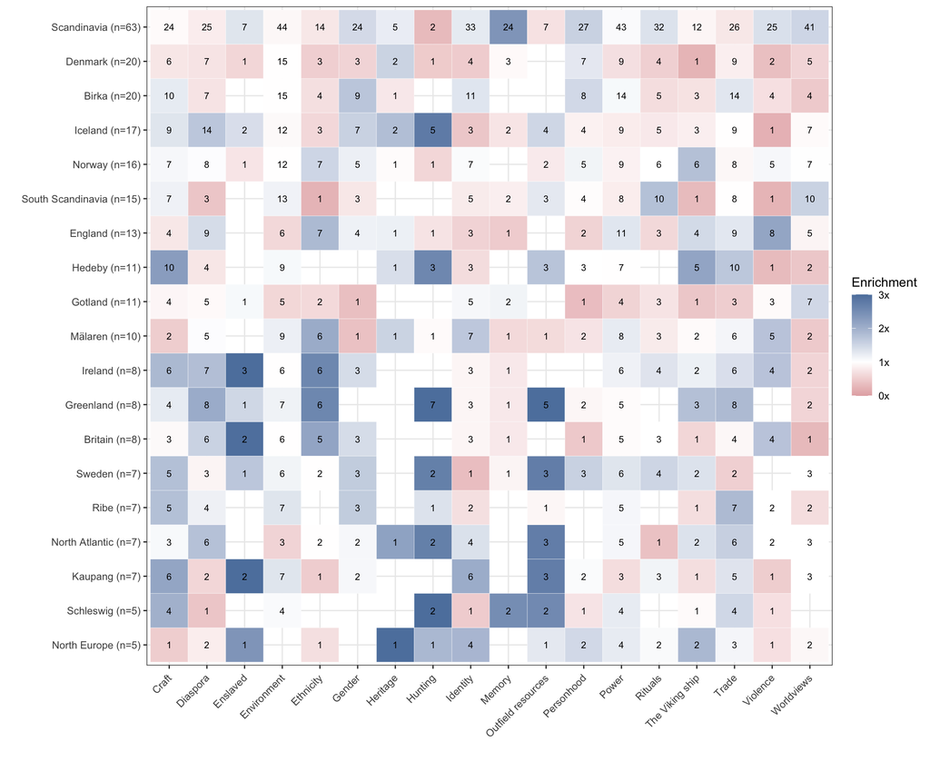

Topic enrichment by region (regions with 5+ tagged papers only). White = topic at corpus average rate for that region; blue = above average; red = below. Cell shows raw count behind the percentage. Capped at 3x so a handful of extreme small-n ratios don’t wash out the rest of the scale.

**Method**

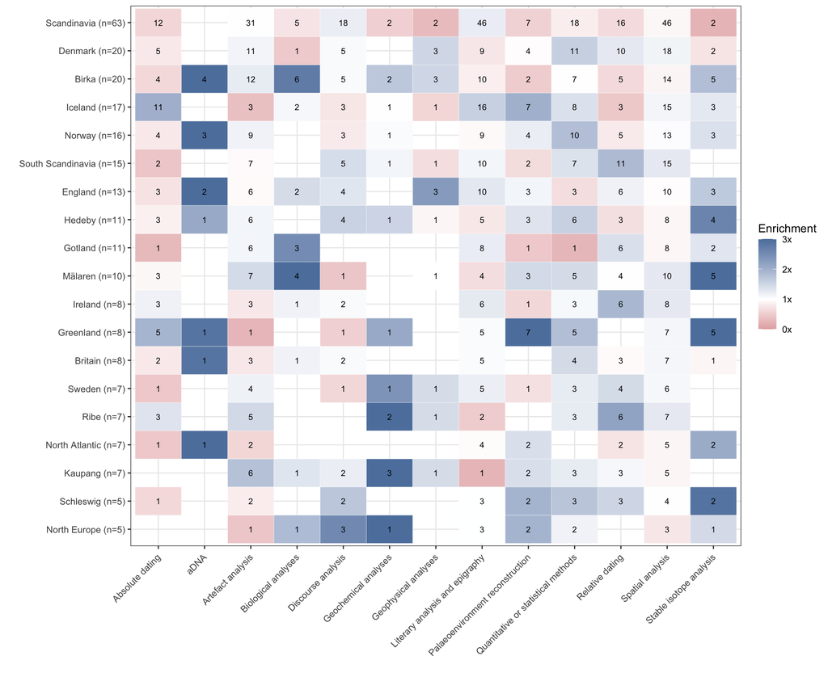

Method enrichment by region (regions with 5+ tagged papers only). Same reading as the topic heatmap above.

**Source of evidence**

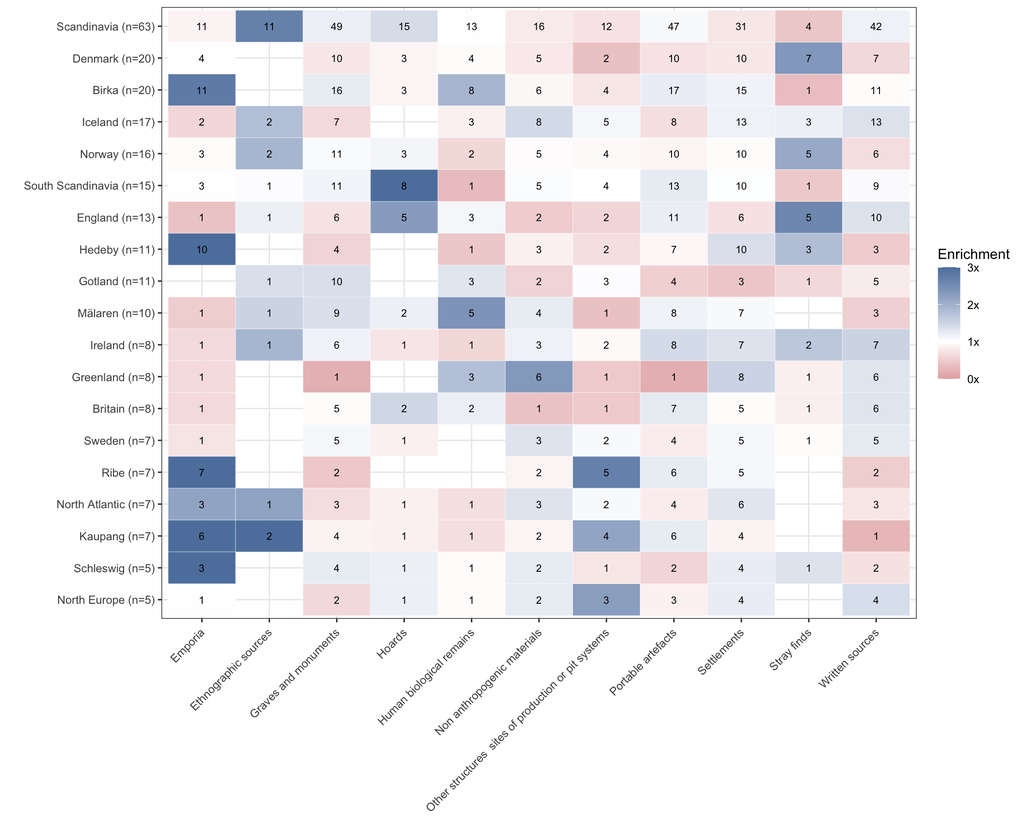

Source-of-evidence enrichment by region (regions with 5+ tagged papers only). Same reading as the topic heatmap above.

### Topic, method, and source by administrative level

The tabset above groups by the raw region token as written in each paper, “Birka” and “Sweden” stay separate rows even though one is inside the other. This section repeats the same topic/method/source enrichment analysis, but grouped at each of the three nesting levels resolved by the region-nesting chunk above instead: admin region, country, and super-region. Requires that chunk to have been run at least once — each tab below checks for its column and explains what to do if it’s missing.

The enrichment baseline here is different from the tabset above, on purpose: each cell compares a group’s rate against the rate among only the papers that resolved to *some* value at that nesting level, not against the whole 369-paper F1 corpus. The flat-token tabset above uses the whole-corpus rate, since every F1 paper is a fair comparison point for a raw region tag. Nesting-level resolution is a narrower subset (only papers whose region successfully resolved up to a country, say), so comparing against the whole corpus would dilute the baseline with papers that never entered this analysis at all and understate real enrichment within the resolved set. Enrichment numbers are therefore not directly comparable between the two tabsets, even when they group the same underlying papers.

**By admin region**

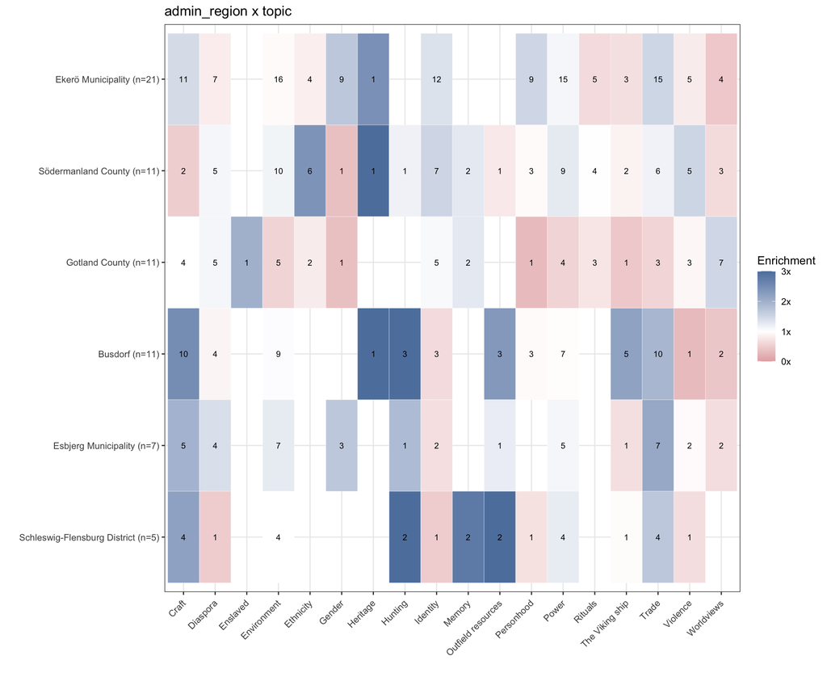

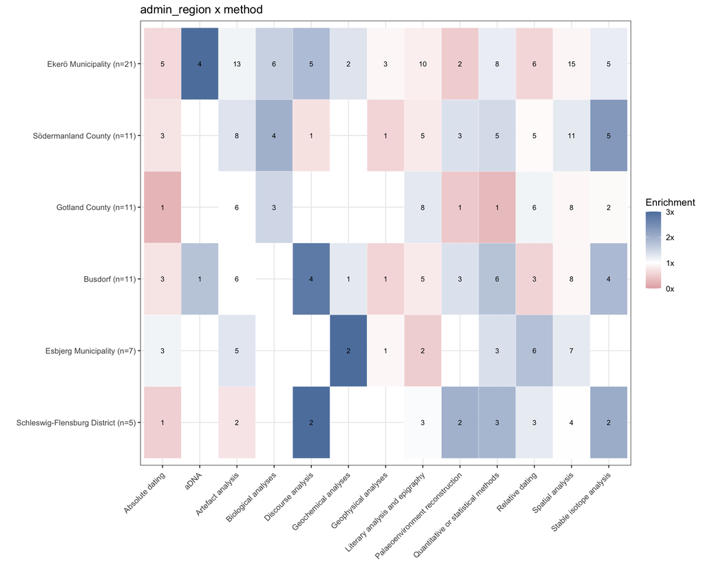

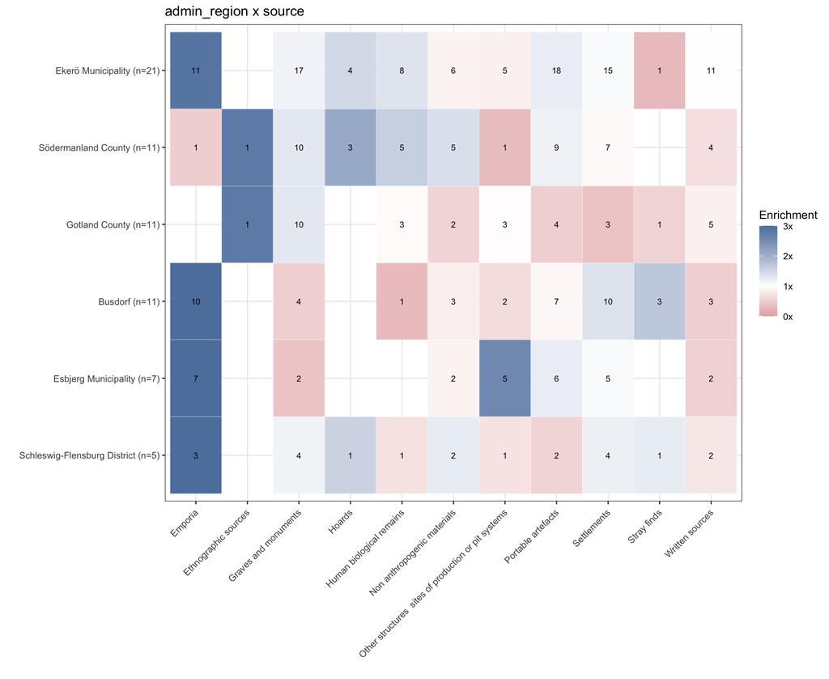

**By country**

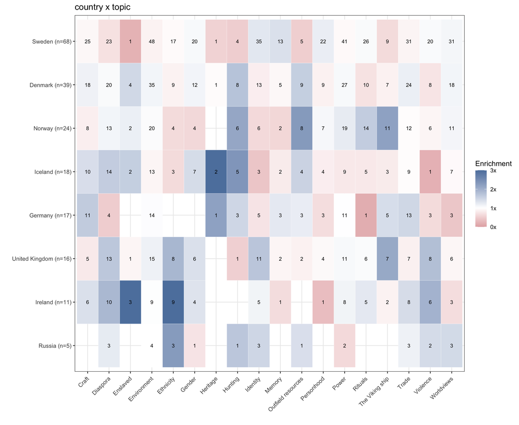

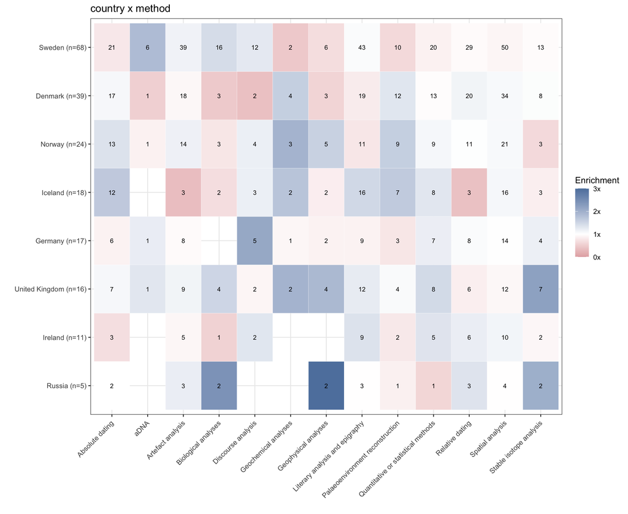

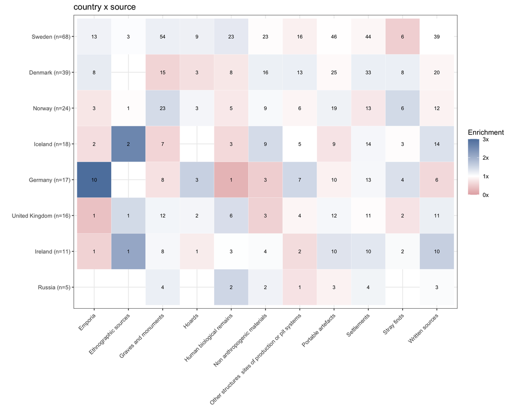

**By super-region**

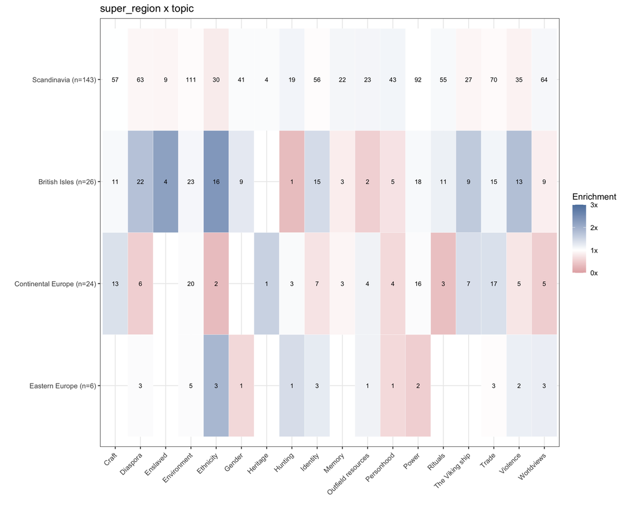

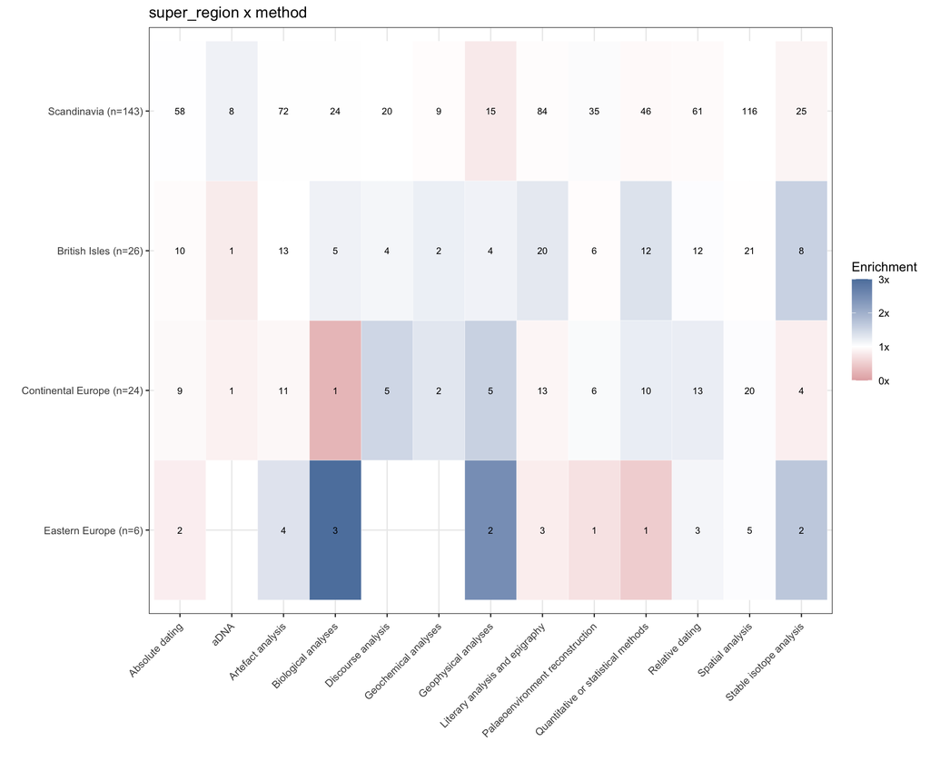

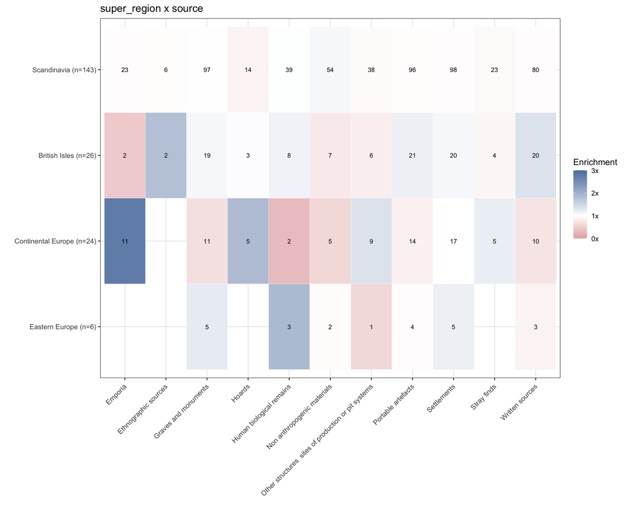

### Change over time

Does the corpus’s geographic focus shift across the years covered, more Iceland/Greenland work recently versus more mainland Scandinavia earlier, or the reverse? Same problem as the other region breakdowns: most tokens have too few papers spread across too many years to support a real per-year trend. Restricted to regions with at least 8 tagged papers (a higher bar than the 5-paper threshold used for the topic/method/source heatmaps above, since splitting an already-small group by year further thins each cell), using the same Wilson-interval and enrichment machinery already defined for Topic, Method, and Source.

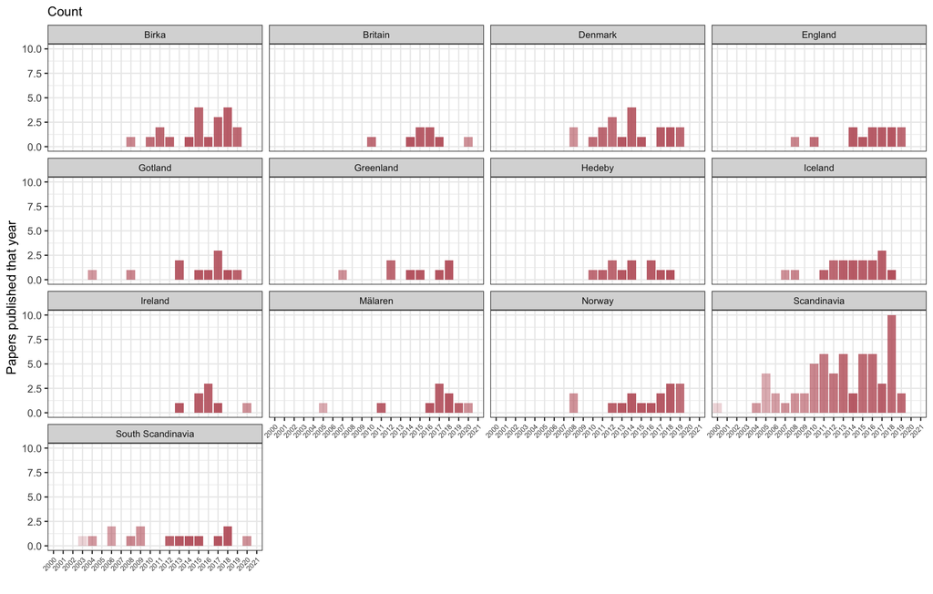

Papers per year, per region (regions with 8+ tagged papers only). Faint bars: few papers that year.

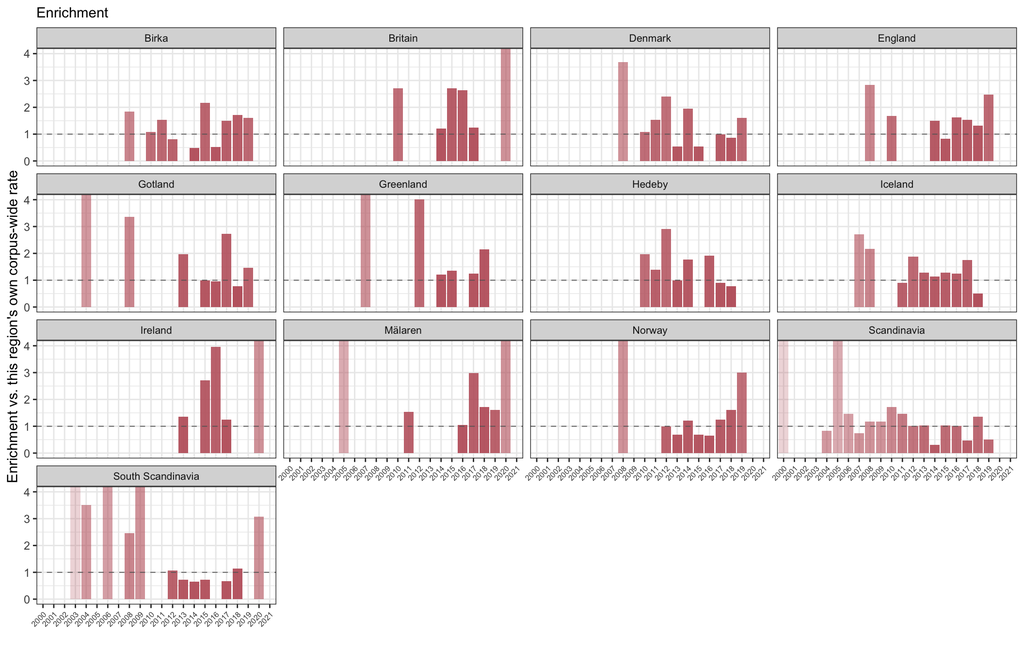

Enrichment per year, per region (regions with 8+ tagged papers only) — that year’s coverage of the region, divided by the region’s own average coverage across the whole corpus (1.0x, dashed line = normal). Faint bars: few papers that year.